# HW1_ DV_SYYarovoy

SYYarovoy

2024-01-16

# 1. Загрузите датасет insurance.csv

```r
insurance <- read.csv("insurance_cost.csv", stringsAsFactors = T)
```

# 2. Выведите гистограммы всех нумерических переменных

```r
# Смотрим общее описание данных
summary(insurance)
```

```
##       age            sex           bmi           children     smoker
##  Min.   :18.00   female:662   Min.   :15.96   Min.   :0.000   no :1064
##  1st Qu.:27.00   male  :676   1st Qu.:26.30   1st Qu.:0.000   yes: 274
##  Median :39.00                Median :30.40   Median :1.000
##  Mean   :39.21                Mean   :30.66   Mean   :1.095
##  3rd Qu.:51.00                3rd Qu.:34.69   3rd Qu.:2.000
##  Max.   :64.00                Max.   :53.13   Max.   :5.000
##        region       charges
##  northeast:324   Min.   : 1122
##  northwest:325   1st Qu.: 4740
##  southeast:364   Median : 9382
##  southwest:325   Mean   :13270
##                  3rd Qu.:16640
##                  Max.   :63770
```

```r
str(insurance)
```

```
## 'data.frame':    1338 obs. of  7 variables:
##  $ age     : int  19 18 28 33 32 31 46 37 37 60 ...
##  $ sex     : Factor w/ 2 levels "female","male": 1 2 2 2 2 1 1 1 2 1 ...
##  $ bmi     : num  27.9 33.8 33 22.7 28.9 ...
##  $ children: int  0 1 3 0 0 0 1 3 2 0 ...
##  $ smoker  : Factor w/ 2 levels "no","yes": 2 1 1 1 1 1 1 1 1 1 ...
##  $ region  : Factor w/ 4 levels "northeast","northwest",..: 4 3 3 2 2 3 3 2 1 2 ...
##  $ charges : num  16885 1726 4449 21984 3867 ...
```

```r
# переменные только numeric
insurance %>%
  select(where(is.numeric) & !where(is.integer)) %>%
  colnames() %>%
  print()
```

```
## [1] "bmi"     "charges"
```

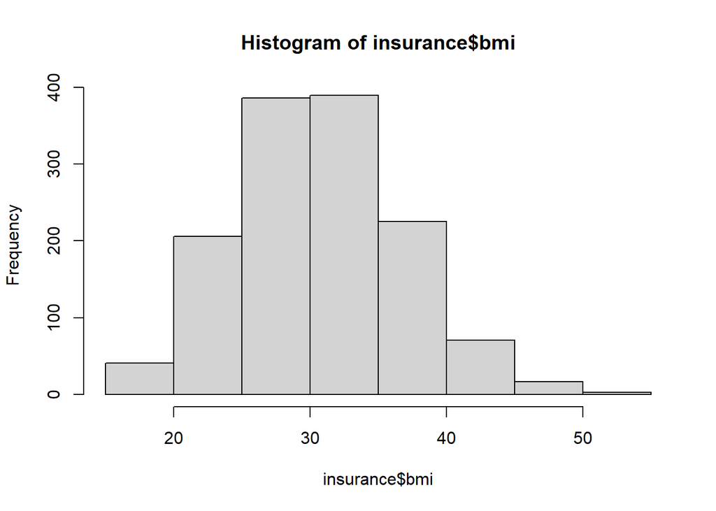

```r
hist(insurance$bmi)
```

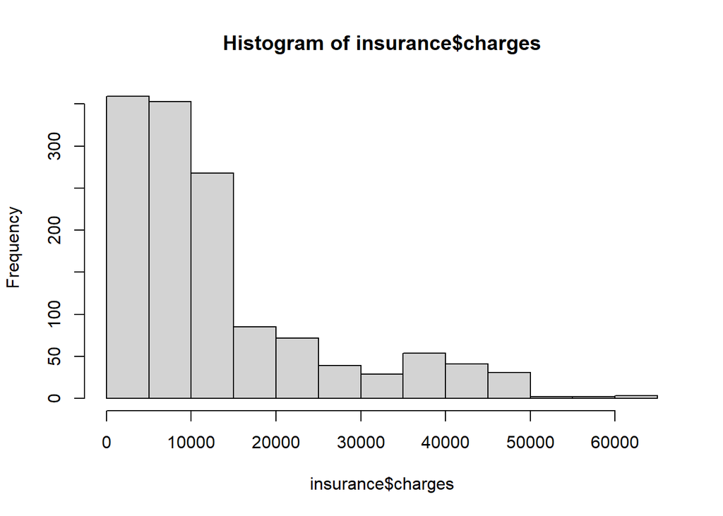

```r
hist(insurance$charges)
```

# 3. Нарисуйте график плотности по колонке charges. Отметьте вертикальные линии средней и медианы на графике. Раскрасьте текст и линии средней и медианы разными цветами. Добавьте текстовые пояснения значения средней и медианы. Подберите тему для графика. Назовите оси.

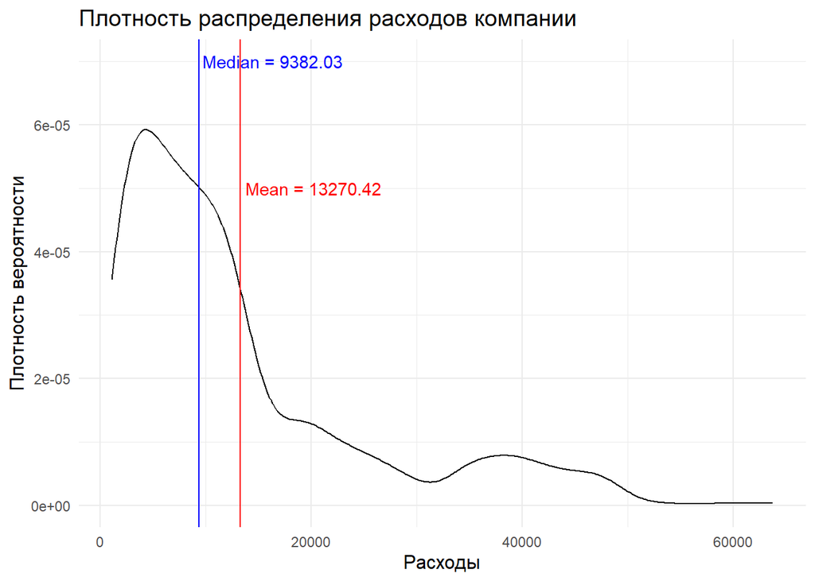

```r
charges_mean <- round(mean(insurance$charges), 2)
charges_median <- round(median(insurance$charges), 2)

charges_density <- ggplot(data = insurance, aes(x = charges)) +
  geom_density() +
  geom_vline(aes(xintercept = charges_mean), color = 'red') +
  geom_vline(aes(xintercept = charges_median), color = 'blue') +
  annotate("text",
           x = charges_mean+7000,
           y = 0.00005,
           label=paste0("Mean = ", charges_mean),
           color = 'red') +
  annotate("text",
           x = charges_median+7000,
           y = 0.00007,
           label=paste0("Median = ", charges_median),
           color = 'blue') +
  theme_minimal() +
  ggtitle('Плотность распределения расходов компании') +
  labs(x = 'Расходы', y = 'Плотность вероятности') +
  theme(
    title = element_text(size = 12),
    axis.title.y = element_text(size=12)
    )

charges_density
```

# 4. Сделайте три box_plot по отношению переменных charges и (1) sex (2) smoker (3) region. Подберите тему для графика. Назовите оси.

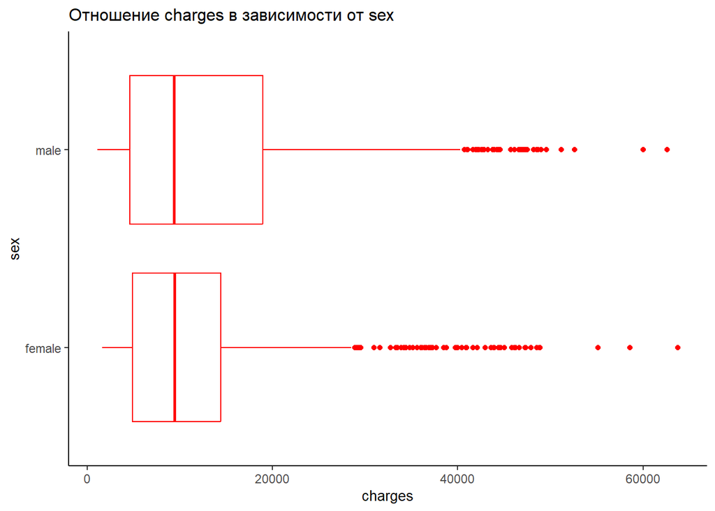

```r
charges_sex <- ggplot() +
  geom_boxplot(data = insurance, aes(x = charges, y = sex), color = 'red') +
  theme_classic() +
  ggtitle('Отношение charges в зависимости от sex') +
  theme(
    title = element_text(size = 10),
    axis.title.y = element_text(size=10)
    )

charges_smoker <- ggplot() +
  geom_boxplot(data = insurance,
               aes(x = charges, y = smoker),
               color = 'orange') +
  theme_minimal() +
  ggtitle('Отношение charges в зависимости от статуса smoker') +
  theme(
    title = element_text(size = 10),
    axis.title.y = element_text(size=10)
    )

charges_region <- ggplot() +
  geom_boxplot(data = insurance,
               aes(x = charges, y = region),
               color = 'green') +
  theme_minimal() +
  ggtitle('Отношение charges в зависимости от region') +
  theme(
    title = element_text(size = 10),
    axis.title.y = element_text(size=10)
    )

charges_sex
```

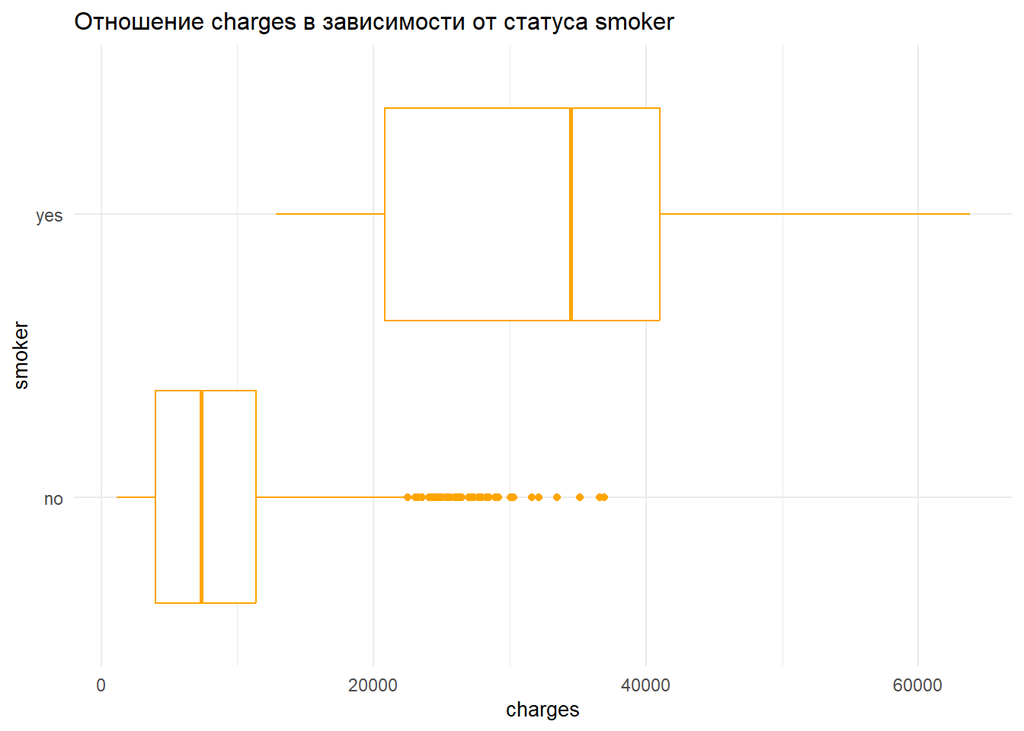

```r
charges_smoker
```

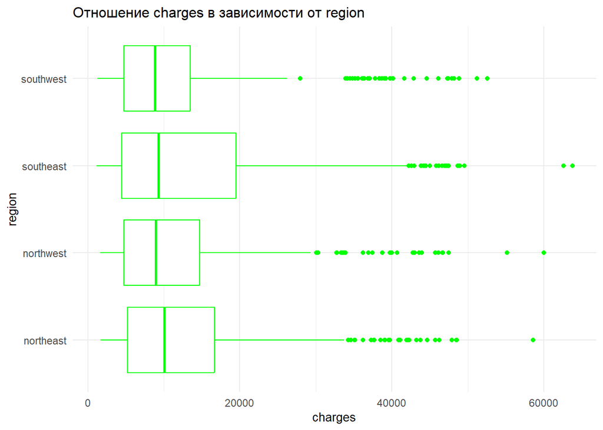

```r
charges_region
```

# 5. Объедините графики из заданий 3 и 4 в один так, чтобы сверху шёл один график из задания 3, а под ним 3 графика из задания 4. Сделайте общее название для графика.

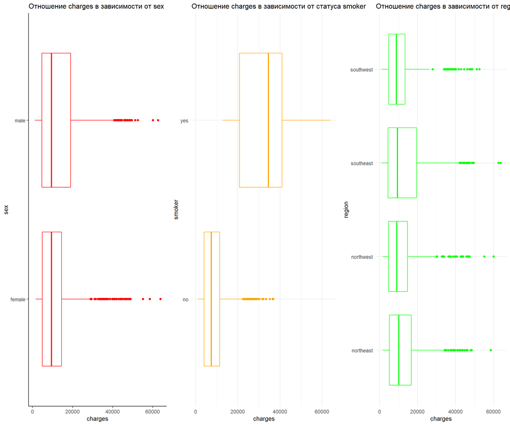

```r
plot4 <- grid.arrange(charges_sex, charges_smoker, charges_region, ncol = 3, nrow = 1)
```

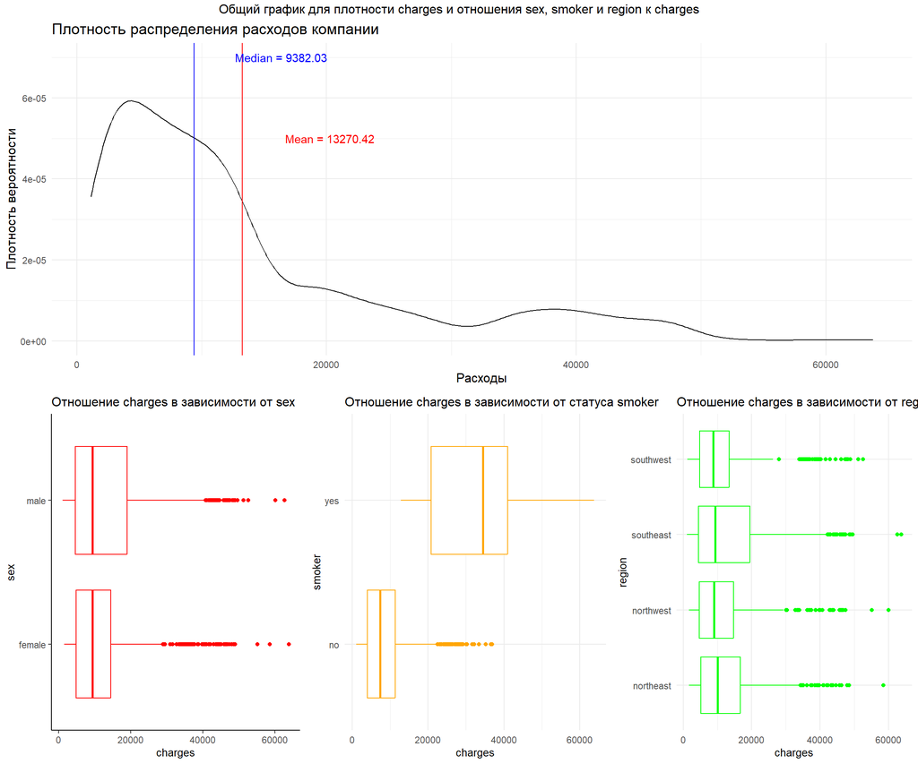

```r
plot34 <- grid.arrange(charges_density, plot4, ncol = 1, nrow = 2, top = "Общий график для плотности charges и отношения sex, smoker и region к charges")
```

```r
plot34
```